# 4th Markdown Assignment

Joey Castillo, Justine Sison, Lester Salvador, Sun Phil Zablan

August 6, 2021

## **Farmers’ livelihood strategies and perceived constraints from poor and non-poor households: A dataset from a field survey in Nghe An, Vietnam**

Quan-Hoang Vuong, PhuPham, My-Hien Nguyen, Cong-Thang Ngo,Phuong-MaiTran, Quy VanKhuc

### **Introduction**

In a study conducted by Quan-Hoang Vuong, et al., forests play a vital role in people’s livelihoods, especially for poor people living in remote and upland areas. However, despite tremendous efforts by the Vietnamese government, further rural development is currently hindered by the existing livelihood and forestry policies, stemming from a limited understanding and/or the lack of scientific advice. The province of Nghe An not only experiences a high rate of deforestation and forest degradation, but also has great potential for afforestation or the process of introducing trees and tree seedlings to an area that has previously not been forested, and reforestation, which can contribute in emission reduction. In addition, living in a poor, mountainous commune, the indigenous people’s income largely depends on agricultural production and products from forests.

Therefore, to have better understanding of rural livelihood associated with forest planting-related constraints, the researchers decided to conduct a survey in the commune of Chau Thai, located in the Nghe An province of Vietnam, in order to devise or/and suggest better sustainable rural development and climate change mitigation policies to the government. Households living within 4 villages of the commune were surveyed through a questionnaire. After collecting data and eliminating some incomplete answers, the data includes 215 observations with information on three aspects: resource structure and the local people’s livelihood strategies, factors hindering production forest planting, the difference between poor and non-poor households, and the personal information of the head of households. It is noted that households are further categorized into poor and non-poor according to Vietnam’s poverty line in rural areas between 2016 and 2020. This primary data could be useful for scholars who want to conduct a further in-depth study with regards to the rural livelihood and poverty rate in rural areas in Vietnam, and/or experts and policymakers to devise a better rural livelihood -improvement policies for farmers and those living in poverty, in the uplands of Vietnam.

With data gathered and presented, it was determined that plantation forest and livestock are major sources of farmers’ income while forestland accounts for over 90% of households’ land, and there is also a disparity in livelihood in areas such as forestland, labor and income between the poor and non-poor households. However, we decided to focus on the relationship between land area and income. We would like to create and present a regression line or a regression graph to determine their relationship.

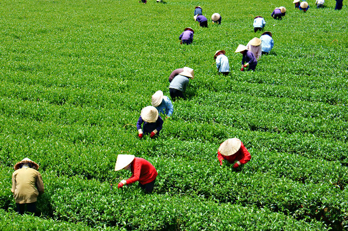

Farming Industry in Vietnam

### **Methodology**

The Chau Thai commune was selected because of these reasons: it is one of 206 poor communes in Nghe An and it has a high potential for afforestation and other projects on climate change mitigation. On another note, the 4 villages selected were the following: Dong Minh, Ban Hat, Thai Quang, and Dong Hin. Data were collected using a field survey consisting of 62 items. They were then converted to .xlsx format for formal analysis into an external application. People in the target area of study were randomly sampled to determine the survey’s respondents. The researchers adopted three steps in designing their study. First, they formed a focus group to help interviewers grasp the data collection procedure and enhance the questionnaire with the aid of the focus group members. Second, they ran a pilot survey with a view to making proper adjustment to the questionnaire until the final version came out. The third and final step is they conducted the survey using a random sampling technique and questionnaire-based face-to-face interviews from the final draft of the questionnaire.

The first part of the questionnaire investigates a households’ land use structure. This part is composed of 9 questions. The second part, which is composed of 15 questions, looks into income structure. The third part is the people’s perceptions towards setbacks in production forest planting, which is composed of 23 questions, in order to obtain the different levels of plantation forest constraints. The last part, which is composed of 15 questions, aims to collect the respondents’ personal information and socioeconomic background.

In order to analyze the relationship between land area and income, we would use a regression line with the data coming from the data set. We would formulate the regression line, and determine the error in coefficients using an external application.

### **Results**

From the data set, the relationship between the land area and income will be analyzed with the use of a regression line. The values from the data set are given as follows:

| Total Land | Total Income (milliom) |
| --- | --- |
| 2.04 | 41.66 |
| 2.02 | 69.17 |
| 0.79 | 51.06 |
| 4.88 | 71.41 |
| 2.81 | 51.85 |
| 8.38 | 114.03 |
| 4.10 | 85.20 |
| 3.20 | 82.00 |
| 1.38 | 54.60 |
| 3.06 | 48.05 |
| 8.36 | 70.10 |
| 2.16 | 58.20 |
| 2.71 | 67.10 |
| 0.97 | 93.97 |
| 1.22 | 123.54 |
| 0.83 | 18.10 |
| 1.11 | 28.98 |
| 0.14 | 22.40 |
| 0.89 | 46.30 |
| 2.12 | 42.70 |
| 0.89 | 62.10 |
| 5.52 | 57.87 |
| 12.10 | 171.83 |
| 2.09 | 100.70 |
| 1.94 | 26.65 |
| 5.35 | 199.05 |
| 4.59 | 201.91 |
| 1.10 | 83.17 |
| 0.60 | 95.65 |
| 6.16 | 80.40 |

[output cut: 185 more lines]

**Table 1.** Total Land and Total Income (million).

The next diagram will show the scatter plot of total income in million versus the total land of the sampled households from the survey in Nghe An, Vietnam.

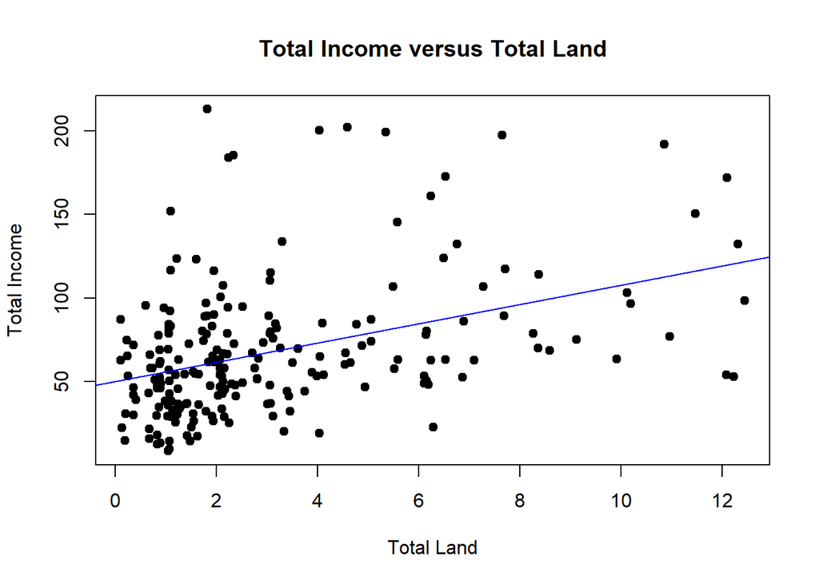

**Graph 1.** Scatter plot of *Total Land* versus *Total Income (million)*.

### *Simple Linear Regression Model*

We will be fitting the data using a simple linear regression model using the least squares method. From the table 1, we will fit it using $\hat{y}=\hat{\beta}_0 +\hat{\beta}_1x$, wherein $\hat{y}$ represents the total income, $x$ represents the total land, and $\hat{\beta}_0$ and $\hat{\beta}_1$ are the estimates for regression coefficients. With the use of the r computation, we can then solve for the fitted simple linear regression model.

```r
x = df$x
y = df$y

Sxy = sum((x - mean(x)) * (y - mean(y)))
Sxx = sum((x - mean(x)) ^ 2)
Syy = sum((y - mean(y)) ^ 2)
c(Sxy, Sxx, Syy)
```

```
## [1]   9599.521   1670.504 342248.264
```

Then we can calculate for the $\hat{\beta}_0$ and $\hat{\beta}_1$.

```r
x = df$x
y = df$y

beta_1_hat = Sxy / Sxx
beta_0_hat = mean(y) - beta_1_hat * mean(x)
c(beta_0_hat, beta_1_hat)
```

```
## [1] 50.145292  5.746483
```

Thus, the fitted simple linear regression model for the graph is
$$\hat{y}=50.145292+5.746483x$$
**Estimating $\sigma^2$, variance**

We can estimate the variance using r.

```r
y_hat = beta_0_hat + beta_1_hat * x
e = y - y_hat
n = length(e)
s2_e = sum(e^2) / (n - 2)
s2_e
```

```
## [1] 1347.816
```

The *estimated variance*, $\sigma^2$ is 1347.816. Regression coefficients are the estimates of an unknown population parameters and gives a description of the relationship between the predictor variable and the response. In a simple linear regression, the coefficients are the values that multiply the predictor values. Suppose that we have the regression equation from earlier, which is $\hat{y}=50.145292+5.746483x$, the $+ 5.746483x$ is the coefficient, $x$ is the predictor, and $+ 50.145292$ is the constant. Since the coefficient has a positive sign, it tells us that as the predictor variable increases, the response variable also increases. To test this relationship, suppose that we want to know the total income if the total land one owns is 4.59, we will be substituting it to the linear regression model that we have computed. The simple line regression model is:
$$\hat{y}=50.145292+5.746483x$$
Now, let’s make a prediction on the total income is the total land one owns is 4.59.
$$\begin{aligned}
\hat{y}&=50.145292+5.746483x\\
\hat{y}&=50.145292+(5.746483)(4.59)\\
\hat{y}&=76.5216
\end{aligned}$$
So, the total income if one owns a total land of 4.59 is approximately 76.52 million.

### **Discussion**

This data may be primarily of use to the “Ministry of Agriculture and Rural Development” primarily located in Vietnam. The allocation of arable farmland around the mountainous terrain the data was derived from can benefit from the use of the model derived by us researchers.

### **Conclusion**

This data will be useful to anyone aiming for a deeper study into the relationship of land and income in the Nghe An province specifically. Vietnamese government agencies, independent researchers, and agriculture entrepreneurs based in Vietnam may use these new findings alongside the original research.

### *Bibliography*

**Data journal used:** Q.-H. Vuong, P. Pham, M.-H. Nguyen, C.-T. Ngo, P.-M. Tran, and Q. V. Khuc, “Farmers’ livelihood strategies and perceived constraints from poor and non-poor households: A dataset from a field survey in Nghe An, Vietnam,” Data in Brief, vol. 36, p. 106991, Jun. 2021, doi: 10.1016/j.dib.2021.106991. **Data set used:** Q.-H. Vuong, P. Pham, M.-H. Nguyen, C.-T. Ngo, P.-M. Tran, and Q. V. Khuc, “Farmers’ livelihood strategies and perceived constraints from poor and non-poor households: A dataset from a field survey in Nghe An, Vietnam,” Data in Brief, vol. 36, p. 106991, Jun. 2021, doi: 10.1016/j.dib.2021.106991.